# Relatório 04

Nicolas Willian Ribeiro

07/05/2025

# 1 Objetivo

Avaliar o desempenho de 4 tipos de antenas para transmissão Wi-Fi em ambientes internos, considerando a intensidade média do sinal recebido em diferentes pontos fixos.

# 2 Apresentação do relatório

Utilizando o modelo DIC iremos verificar quatro modelos de antenas diferentes para verificar se existe uma diferença significativa entre elas, e caso exista, qual delas se sai melhor no cenario na qual o teste esta sendo aplicado.

Abaixo estão as bibliotecas utilizadas no R studio.

```r
 #Manipulação de dados (pipes, group_by, summarise etc.)
library(dplyr)
```

```r
# Gráficos bonitos, como boxplot
library(ggplot2)

# Teste de Tukey com agrupamento de médias
library(agricolae)
```

Começamos a analise com a colheta de dados, no estudo em questão os a intencidade de sinal.

```r
# Banco de Dados
dados <- read.table(header = TRUE, text = "
antena sinal
Dipolo -49.121
Dipolo -48.460
Dipolo -44.883
Dipolo -47.859
Dipolo -47.741
Direcional -39.427
Direcional -41.309
Direcional -43.898
Direcional -43.030
Direcional -42.668
Omnidirecional -43.797
Omnidirecional -45.352
Omnidirecional -45.279
Omnidirecional -45.801
Omnidirecional -47.001
Patch -41.856
Patch -43.403
Patch -46.360
Patch -43.158
Patch -44.567
")

dados$antena <- as.factor(dados$antena)
```

Inicio da analise dos dados:

```r
# Analise Descritiva:

# Coeficiente de variação função
cv <- function(x) sd(x) / mean(x) * 100

# Geral
media_geral <- mean(dados$sinal)
desvio_geral <- sd(dados$sinal)
cv_geral <- cv(dados$sinal)

cat("Média Geral:", media_geral, "\n")
```

```
## Média Geral: -44.7485
```

```r
cat("Desvio Padrão Geral:", desvio_geral, "\n")
```

```
## Desvio Padrão Geral: 2.541911
```

```r
cat("CV Geral (%):", cv_geral, "\n")
```

```
## CV Geral (%): -5.680439
```

```r
# Por tratamento
resumo <- dados %>%
  group_by(antena) %>%
  summarise(
    Media = mean(sinal),
    Desvio = sd(sinal),
    CV = cv(sinal) * -1
  )

print(resumo)
```

```
## # A tibble: 4 × 4
##   antena         Media Desvio    CV
##   <fct>          <dbl>  <dbl> <dbl>
## 1 Dipolo         -47.6   1.62  3.41
## 2 Direcional     -42.1   1.75  4.15
## 3 Omnidirecional -45.4   1.15  2.53
## 4 Patch          -43.9   1.69  3.86
```

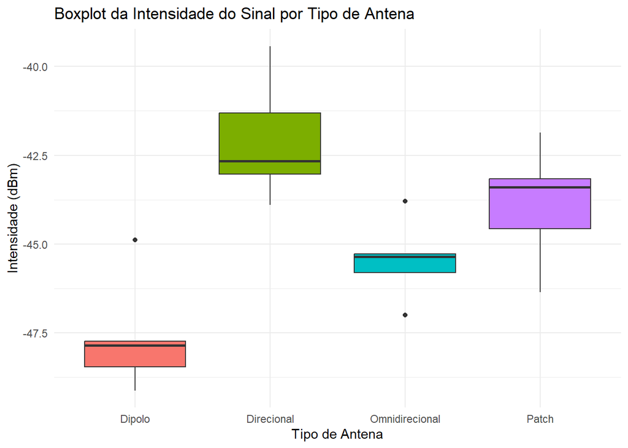

```r
ggplot(dados, aes(x = antena, y = sinal, fill = antena)) +
  geom_boxplot() +
  theme_minimal() +
  labs(title = "Boxplot da Intensidade do Sinal por Tipo de Antena",
       x = "Tipo de Antena", y = "Intensidade (dBm)") +
  theme(legend.position = "none")
```

```r
# Analise ANOVA

modelo <- aov(sinal ~ antena, data = dados)
summary(modelo)
```

```
##             Df Sum Sq Mean Sq F value   Pr(>F)
## antena       3  83.29  27.764   11.25 0.000322 ***
## Residuals   16  39.47   2.467
## ---
## Signif. codes:  0 '***' 0.001 '**' 0.01 '*' 0.05 '.' 0.1 ' ' 1
```

```r
# Teste de Comparações Múltiplas

tukey <- HSD.test(modelo, "antena", group = TRUE)
print(tukey)
```

```
## $statistics
##    MSerror Df     Mean        CV      MSD
##   2.467105 16 -44.7485 -3.510066 2.842135
##
## $parameters
##    test name.t ntr StudentizedRange alpha
##   Tukey antena   4         4.046093  0.05
##
## $means
##                   sinal      std r        se     Min     Max     Q25     Q50
## Dipolo         -47.6128 1.621826 5 0.7024393 -49.121 -44.883 -48.460 -47.859
## Direcional     -42.0664 1.745372 5 0.7024393 -43.898 -39.427 -43.030 -42.668
## Omnidirecional -45.4460 1.151084 5 0.7024393 -47.001 -43.797 -45.801 -45.352
## Patch          -43.8688 1.693158 5 0.7024393 -46.360 -41.856 -44.567 -43.403
##                    Q75
## Dipolo         -47.741
## Direcional     -41.309
## Omnidirecional -45.279
## Patch          -43.158
##
## $comparison
## NULL
##
## $groups
##                   sinal groups
## Direcional     -42.0664      a
## Patch          -43.8688     ab
## Omnidirecional -45.4460     bc
## Dipolo         -47.6128      c
##
## attr(,"class")
## [1] "group"
```

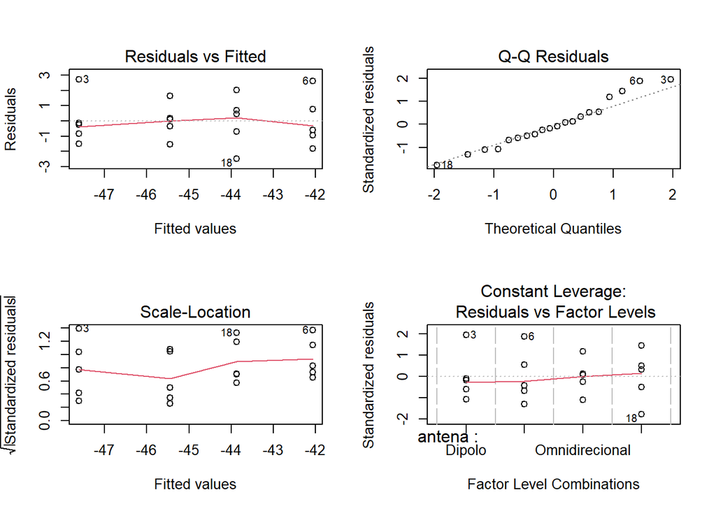

```r
# Análise de Resíduos

par(mfrow = c(2,2))
plot(modelo)
```

# 3 Conclusão

Nossa analise descritiva nos trouxe que cada modelo de antena possui um nivel aceitavel de variação de sinal, ou seja, tudo indica que não possui uma fonte variabilidade que esteja tornando os dados heterogenios e podemos seguir com o metedo DIC.

O Boxplot já traz com ele que um determinado modelo de antena possui um nivel de sinal melhor, menos negativo, porém podemos ver que esse modelo possui uma maior variação de nivel de sinal. Olhando novamente a analise descritiva já era de se esperar algo assim pois o coeficiente de variação do modelo com o a media menos negativa era o maior, isso não significa que sempre o melhor nivel vai ter alta variabilidade apenas explica o que o grafico nos mostra.

A ANOVA já rejeita a hipótese de que todas as antenas são estatisticamente iguais, mesmo não indicando qual deles é a melhor a analise nos diz que há diferença entre dois modelos de antenas pelo menos.

O teste de comparações multiplas (Tukey) classifica os modelos com base no seu desempenho e na igualdade estatistica entre eles, é aqui aonde vemos quais modelos são estatisticamente iguais e qual deles se saiu melhor que os demais, notamos que existe uma igualdade entre dos modelos Direcionais/Patch, Patch/Omnidirecional e Omninidirecional/Dipolo, porem isso não seguinifica que todas são estatisticamente iguais, podemos dizer que os modelos Patch e Omnidirecional não possuem diferenças muito claras entre elas e com os modelos nas extremidades, porem o modelo Direcional possui o melhor nivel de intensidade de sinale apenas o modelo Patch apresenta niveis proximos, por maios que o modelo Omnidirecional possua niveis proximos do modelo Patch seus niveis não são suficientes para a proximidade com o modelo Direcional.

# 4 Comentario

Ao estudar antenas nos aprendemos a diferença entre as antenas e suas caracteristicas, os resultados aprensentados atendem as expectativas iniciais afinal uma antena direcional concentra o sinal em uma detarminada area ja o Dipolo, apesar de ser equivalente a uma antena Omnidirecional dupla, espalhar mais o sinal. É importante dizer que o desempenho das antenas pode mudar draticamente de acordo com o local aonde elas foram colocadas e o local da colheta de dados, ou seja o Dipolo pode sim se sair melhor que o Direcional dependendo de como forem instalados.